# Manipulate Package

The [`manipulate`](http://cran.r-project.org/web/packages/manipulate/index.html) from RStudio allows you to create simple Tcl/Tk operators for interactive visualization. I will use it for a simple slider to view different slices of an image.

```r
library(manipulate)
```

# fslr package

I’m calling the `fslr` package because I know that if you have it installed, you will likely have FSL and have a 1mm T1 template from MNI in a specific location. `fslr` also loads the `oro.nifti` package so that `readNIfTI` is accessible after loading `fslr`. You can download a test NIfTI image [here](http://www.bic.mni.mcgill.ca/ServicesAtlases/ICBM152NLin2009) if you don’t have access to any and don’t have FSL downlaoded.

Here I will read in the template image:

```r
library(fslr)
options(fsl.path='/usr/local/fsl')
template = file.path(fsldir(), "data/standard",
                     "MNI152_T1_1mm_brain.nii.gz")
img = readNIfTI(template)
```

# The iplot function

The `iplot` function defined below takes in a `nifti` object, the specific plane to be plotted and additional options to be passed to `oro.nifti::image`. The function is located [on my GitHub here](https://raw.githubusercontent.com/muschellij2/HopStat/gh-pages/A_small_neuroimage_interactive_plotter/A_small_neuroimage_interactive_plotter.R).

```r
iplot = function(img, plane = c("axial",
                                "coronal", "sagittal"), ...){
  ## pick the plane
  plane = match.arg(plane, c("axial",
                             "coronal", "sagittal"))
  # Get the max number of slices in that plane for the slider
  ns=  switch(plane,
              "axial"=dim(img)[3],
              "coronal"=dim(img)[2],
              "sagittal"=dim(img)[1])
  ## run the manipulate command
  manipulate({
    image(img, z = z, plot.type= "single", plane = plane, ...)
    # this will return mouse clicks (future experimental work)
    pos <- manipulatorMouseClick()
    if (!is.null(pos)) {
      print(pos)
    }
  },
  ## make the slider
  z = slider(1, ns, step=1, initial = ceiling(ns/2))
  )
}
```

# Example plots

Here are some examples of how this `iplot` function would be used:

```r
iplot(img)
iplot(img, plane = "coronal")
iplot(img, plane = "sagittal")
```

The result will be a plotted image of the slice with a slider. This is most useful if you run it within RStudio.

Below are 2 example outputs of what you see in RStudio:

Slice 91:

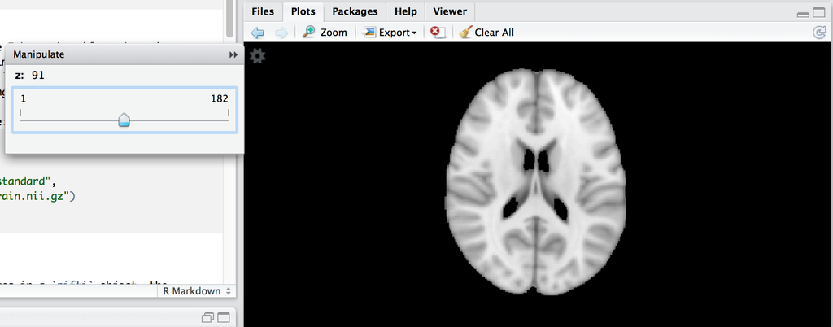

Slice 145:

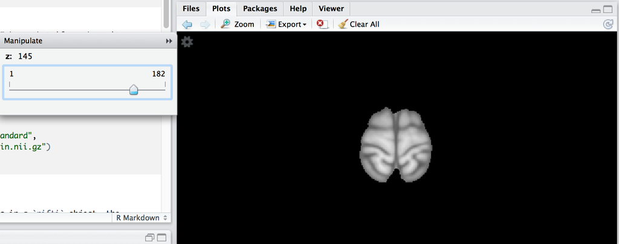

# Conclusions

The `iplot` function allows users to interactively explore neuroimages. The plotting is not as fast as I’d like, I may try to speed up the `oro.nifti::image` command or implement some subsampling. It does however show a proof of concept how interactive neuroimaging visualization can be done in `R`.

## Note

`manipulate` must be run in RStudio for manipulation. The `fslr` function `fslview` will call FSLView from FSL for interactive visualization. This is an option of interactive neuroimaging “in `R`”, but not a real or satisfactory implementation for me (even though I use it frequently). If anyone has implemented such a solution in `R`, I’d love to hear about it.